# Big Data Midterm

## Introduction to Big Data Midterm

Assign date: 2018-2-08

Due date: 2018-2-16 11:59pm

Please submit only one copy of your Jupyter Notebook file with your answers for each question provided in the following cells below to Moodle. There will be no extensions or excemptions.

**You will lose 10% each day your submission is late.**

Please do not post any answers to the general question forum. You can however ask for technical help on the course page if you are having actualy technical issues. I reserve the right to delete any question/response that I deem being too much "begging for hints" in nature. You may email me directly at mtenney@yorku.ca if you have any questions, but do note I will not provide you any answers and my response may take up to 48hrs. And of course, you're free to use any class material, the Internet, or additional resources to complete the exam. The exam covers material from weeks 1-4 inclusively.

**Note you MUST RUN THE CODE and print out the required results when submitting. Any empty cells or un-run code will not be accepted.**

**1) Import the following libraries to your notebook (you can use alias' if you want) in the cell below:**  
pandas, seaborn, os, matplotlib.pyplot  
**And** add the following flag: %matplotlib inline

```python
import matplotlib.pyplot as plt
```

```python
import pandas as pd
import seaborn as sns
import os
%matplotlib inline
```

**2) Index a list in Python**  
Run the code below, it will give a result of 4. If we want to get ONLY the number 8 from the list of lists below, how would you alter the code? Alter the code directly and run to print the desired output.

```python
question2 = [[1,2],[3,4],[5,6],[7,[8,9]]]
print question2[3][1][0]
```

```
8
```

**3) Define a variable called bigdata, to be a list in python with the following elements and print only the last two elements of the list:**  
1, "Big Data Class", 2, "Is Really Fun",3, "I Love Python"

```python
bigdata=[1,"Big Data Class",2,"Is Really Fun",3,"I Love Python"]
print bigdata[-2],bigdata[-1]
```

```
3 I Love Python
```

**4) Cast the following list to be a string in Python:**  
Define the list [1,2,4,3,'k'] and cast it to a string where you print out '1243k'. Insert your code below.

```python
list1 = [1,2,4,3,'k']
''.join(str(x) for x in list1)

#list1 = [1,2,4,3,'k']
#x=''
#for i in range(len(list1)):
#    x=x+str(list1[i])
#print(x)
```

```
'1243k'
```

**5) Test whether the two lists are equal too each other and if not what elements are shared between the two lists.**

list1 = ['1',2,'3',4,5]

list2 = [1,2,3,4,'5',6]  
Define the lists and print whether the lists are equal to one another, and find which elements are a match. (*Hint you can go element by element or use you can use a "for" loop, or, you can use a different data structure all together*).

```python
list1 = ['1',2,'3',4,5]
list2 = [1,2,3,4,'5',6]

if set(list1) == set(list2):
    print "List are equal"
else :
    print "Lists are not equal and common elements are " + str(list(set(list1).intersection(set(list2))))
```

```
Lists are not equal and common elements are [2, 4]
```

**6) Convert list2 to be indentical to list1 by casting the datatypes to match those in list1.**

```python
list1 = ['1',2,'3',4,5]
list2 = [1,2,3,4,'5',6]

list1 = list1 + [6]

list2[0] = str(list2[0])
list2[2] = str(list2[2])
list2[4] = int(list2[4])

print list1
print list2
```

```
['1', 2, '3', 4, 5, 6]
['1', 2, '3', 4, 5, 6]
```

**7) What are the "5 V's" commonly used to describe Big Data?** Write your answer below.

```python
Velocity, Volume, Value, Variety, and Veracity
```

**8) Finish the quote:**  
*"All models are wrong. Some are [...]"*

```python
useful.
```

**9) If a variable dogs = 103x23/2 and a variable cats = 10x12x4, Use python to determing if dogs are greater than cats.**

```python
dogs = 103*23/2
cats = 10*12*4

if dogs > cats:
    print "dogs are greater"
else:
    print "cats are greater"
```

```
dogs are greater
```

**10) What is the name for the 3 primary measures of central tendency and give their definition**

the mode, the median and the mean

The mode is the most commonly occurring value in a distribution. The median is the middle value in distribution when the values are arranged in ascending or descending order. The mean is the sum of the value of each observation in a dataset divided by the number of observations. This is also known as the arithmetic average.

**11) Calculate the descriptive statistice for each of the above central measures in Python on this list of numbers and print out the values:**

[12,44,23,2,1,66,7,85,3,34,23,6,34,23,7,21,14,34,23,88]  
*(Hint: it might be easier to import a function from some other library)*

```python
list3 = [12,44,23,2,1,66,7,85,3,34,23,6,34,23,7,21,14,34,23,88]
n = len(list3)
sum_of_elements = sum(list3)
mean = sum_of_elements/float(n)
print (mean)

sorted_elements = sorted(list3)

middle_elements = [sorted_elements[int(n)/2], sorted_elements[int(n)/2 - 1]]

median_of_elements = sum(middle_elements) / 2.0

print float(median_of_elements)

highest_freq, highest_freq_elem = 0, 0
for elem in sorted_elements:
    current_count = sorted_elements.count(elem)
    if (current_count > highest_freq):
        highest_freq = current_count
        highest_freq_elem = elem

mode = highest_freq_elem
print mode

#import statistics
#list1 = [12,44,23,2,1,66,7,85,3,34,23,6,34,23,7,21,14,34,23,88]
#x = statistics.mean(list1)
#print(x)
#y = statistics.median(list1)
#print(y)
#z = statistics.mode(list1)
#print(z)
```

```
27.5
23.0
23
```

**12) Delete the empty cell between question 12 (this one) and Question 13 from the Jupyter notebook**

**13) Create a list, called mylist, containing a sequential list of numbers that starts with 2 and stops at 1000, counting by 2's in Python**

```python
mylist=[]
for i in range(2,1000,2):
    mylist.append(i)
print (mylist)
```

```
[2, 4, 6, 8, 10, 12, 14, 16, 18, 20, 22, 24, 26, 28, 30, 32, 34, 36, 38, 40, 42, 44, 46, 48, 50, 52, 54, 56, 58, 60, 62, 64, 66, 68, 70, 72, 74, 76, 78, 80, 82, 84, 86, 88, 90, 92, 94, 96, 98, 100, 102, 104, 106, 108, 110, 112, 114, 116, 118, 120, 122, 124, 126, 128, 130, 132, 134, 136, 138, 140, 14…
```

**14) Is the sum of the first 50 elements in "mylist" greater than the last element of "mylist"?**  
Use Python below to print out the answer. (mylist is defined in question 13).

```python
a = 0
for x in range(50):
    a = a + mylist[x]

if a > mylist[-1]:
    print ("First 50 elements greater than " + str(mylist[-1]))
else:
    print ("Last element is greater")
```

```
First 50 elements greater than 998
```

**15) What is the length of "mylist"?**

```python
len(mylist)
```

```
499
```

16) Create another list, called my2ndlist, containing a list of numbers starting at 1002 and stops at 1052,counting by 3's in Python.  
THEN concatenate my2ndlist with mylist into a new list called theMegaList.  
Print theMegaList below.

```python
my2ndlist=[]
for x in range(1002,1052,3):
    my2ndlist.append(x)
print (my2ndlist)

theMegalist=mylist + my2ndlist
print (theMegalist)
```

```
[1002, 1005, 1008, 1011, 1014, 1017, 1020, 1023, 1026, 1029, 1032, 1035, 1038, 1041, 1044, 1047, 1050]
[2, 4, 6, 8, 10, 12, 14, 16, 18, 20, 22, 24, 26, 28, 30, 32, 34, 36, 38, 40, 42, 44, 46, 48, 50, 52, 54, 56, 58, 60, 62, 64, 66, 68, 70, 72, 74, 76, 78, 80, 82, 84, 86, 88, 90, 92, 94, 96, 98, 100, 102, 104, 106, 108, 110, 112, 114, 116, 118, 120, 122, 124, 126, 128, 130, 132, 134, 136, 138, 140, 14…
```

**17) What is the index for the value 822 in theMegaList?**

```python
theMegalist.index(822)
```

```
410
```

**18) Write a for loop that will test if an element in theMegaList is an even or odd number and keeps a count of how many of each there are in the list.**  
Print out the total number of even and odd numbers found in theMegalist below.

```python
odd=[]
even=[]

for x in theMegalist:
    if x%2==0:
        even.append(x)
    else:
        odd.append(x)
count_odd = len(odd)
count_even = len(even)

print ("There are " + str(count_odd) + " odd and " + str(count_even) + " even numbers")
```

```
There are 8 odd and 508 even numbers
```

**19) Write a brief definition of what Data Latency and the difference between "real-time" and "near-time" data.**

Data Latency refers to how much time delay exists between an actual event happening to the data and database being made aware of it. It can also refer to how frequently data is being updated.

Real Time: Low latency describes the condition when there is a “small” amount of time between a real event and the data is updated to reflect it. Depending on the application, low latency may be sub second in an automation environment and several minutes in a business environment. Near Time: Refers to the latency that is less than a day but greater than an hour. High latency describes the condition when the delay is larger and typically measured in hours or days.

**19) What does the statistic Standard Deviation tell you about a numerical dataset?**

```python
The standard deviation of a dataset gives you a measure of how spread out it is.
On an average, it helps you ascertain how close each point is from the mean.
```

**20) Suppose you have the following loop:**

> things = [1,2,3,5,6,7,8,9,10]  
> previous_thing = 0  
> for thing in things:

> > new_thing = thing * previous_thing  
> > x = 3+previous_thing  
> > previous_thing = thing

**At the end of the loop:**

> **What does new_thing equal?**  
> **What does x equal?**

```python
new_thing = 90
x = 12
```

**21) What's the difference between Zero and None or Null?**

Zero is a valid value. It is of integer datatype. NULL is undefined, unknown or no value. E.g. If someone have 0 money, it means that person have no money. However, if he have NULL amount of money then we are not sure how many money he has.

**22) In the following loop:**

> x = 1  
> sure_thing = True  
> while sure_thing:

> > x = x +100  
> > if x < 20001:

> > > x = x-1  
> > > else:  
> > > sure_thing = False

**What does x equal to make our sure_thing False?**

```python
20099
```

**Based on the DataFrame df and df1 defined below, add needed code to answer the following questions.**

```python
#from pandas import Series, DataFrame
import pandas as pd
raw_data = {'first_name': ['Jason', 'Jason', 'Tina', 'Jake', 'Amy'],
        'last_name': ['Miller', 'Miller', 'Ali', 'Milner', 'Milner'],
        'age': [42, 42, 36, 24, 73],
        'preTest': [4, 4, 31, 2, 3],
        'postTest': [25, 25, 57, 62, 70]}
df = pd.DataFrame(raw_data, columns = ['first_name', 'last_name', 'age', 'preTest', 'postTest'])
df1 = df
```

**23) What are the column names in df1?print the result.**

```python
print (df1.columns.values)
#print (list(df1))
```

```
['first_name' 'last_name' 'age' 'preTest' 'postTest']
```

**24) What is the average (mean) of the preTest and postTest scores?print the result.**

```python
print (df1['preTest'].mean())
print (df1['postTest'].mean())

#count = len(raw_data['preTest'])
#Mean = float(sum(raw_data['preTest']))/count
#print (Mean)
#count = len(raw_data['postTest'])
#Mean = float(sum(raw_data['postTest']))/count
#print (Mean)
```

```
8.8
47.8
```

**25) Remove duplicated rows in df based on last_name only. Instead of keeping the first value, now keep the last of the duplicated values.print the result.**

```python
df.drop_duplicates('last_name',keep='last')
```

|  | first_name | last_name | age | preTest | postTest |
| --- | --- | --- | --- | --- | --- |
| 1 | Jason | Miller | 42 | 4 | 25 |
| 2 | Tina | Ali | 36 | 31 | 57 |
| 4 | Amy | Milner | 73 | 3 | 70 |

**26) Remove duplicated rows in df1 based on both first_name and last_name. print the result.**

```python
df1.drop_duplicates(subset=['first_name','last_name'])
```

|  | first_name | last_name | age | preTest | postTest |
| --- | --- | --- | --- | --- | --- |
| 0 | Jason | Miller | 42 | 4 | 25 |
| 2 | Tina | Ali | 36 | 31 | 57 |
| 3 | Jake | Milner | 24 | 2 | 62 |
| 4 | Amy | Milner | 73 | 3 | 70 |

*Use the dataframe defined in the following cell to answer the next few questions*:

```python
from pandas import Series, DataFrame
import pandas as pd
from numpy.random import randn
import numpy as np
np.random.seed(42)
randomdata = DataFrame(np.random.randn(400, 4))
print randomdata
%matplotlib inline
```

```
            0         1         2         3
0    0.496714 -0.138264  0.647689  1.523030
1   -0.234153 -0.234137  1.579213  0.767435
2   -0.469474  0.542560 -0.463418 -0.465730
3    0.241962 -1.913280 -1.724918 -0.562288
4   -1.012831  0.314247 -0.908024 -1.412304
5    1.465649 -0.225776  0.067528 -1.424748
6   -0.544383  0.110923 -1.150994  0.375698
7   -0.600639 -0.291694 -0.601707  1.852278
8   -0.013497 -1.057711  0.822545 -1.220844
9    0.208864 -1.959670 -1.328186  0.196861
10   0.738467  0.171368 -0.115648 -0.301104
11  -1.478522 -0.719844 -0.460639  1.057122
12   0.343618 -1.763040  0.324084 -0.385082
13  -0.676922  0.611676  1.031000  0.931280
```

[output cut: 49 more lines]

**27) Use the "describe" function to summarize the randomdata created above.**

```python
randomdata.describe()
```

|  | 0 | 1 | 2 | 3 |
| --- | --- | --- | --- | --- |
| count | 400.000000 | 400.000000 | 400.000000 | 400.000000 |
| mean | 0.035296 | 0.041202 | 0.046713 | 0.035939 |
| std | 0.924153 | 1.028034 | 0.997816 | 1.024632 |
| min | -2.650970 | -2.896255 | -3.241267 | -2.921350 |
| 25% | -0.612942 | -0.651856 | -0.602684 | -0.683766 |
| 50% | 0.052292 | 0.037928 | 0.036043 | 0.047190 |
| 75% | 0.634986 | 0.676014 | 0.652834 | 0.744011 |
| max | 2.526932 | 3.852731 | 3.078881 | 2.720169 |

**28) Identify the rows which contains at least one item with absolute value greater than 1**

```python
randomdata[(abs(randomdata[[0,1,2,3]]) > 1).any(axis='columns')]
```

|  | 0 | 1 | 2 | 3 |
| --- | --- | --- | --- | --- |
| 0 | 0.496714 | -0.138264 | 0.647689 | 1.523030 |
| 1 | -0.234153 | -0.234137 | 1.579213 | 0.767435 |
| 3 | 0.241962 | -1.913280 | -1.724918 | -0.562288 |
| 4 | -1.012831 | 0.314247 | -0.908024 | -1.412304 |
| 5 | 1.465649 | -0.225776 | 0.067528 | -1.424748 |
| 6 | -0.544383 | 0.110923 | -1.150994 | 0.375698 |
| 7 | -0.600639 | -0.291694 | -0.601707 | 1.852278 |
| 8 | -0.013497 | -1.057711 | 0.822545 | -1.220844 |
| 9 | 0.208864 | -1.959670 | -1.328186 | 0.196861 |
| 11 | -1.478522 | -0.719844 | -0.460639 | 1.057122 |
| 12 | 0.343618 | -1.763040 | 0.324084 | -0.385082 |
| 13 | -0.676922 | 0.611676 | 1.031000 | 0.931280 |
| 15 | -0.479174 | -0.185659 | -1.106335 | -1.196207 |
| 16 | 0.812526 | 1.356240 | -0.072010 | 1.003533 |
| 17 | 0.361636 | -0.645120 | 0.361396 | 1.538037 |
| 18 | -0.035826 | 1.564644 | -2.619745 | 0.821903 |
| 19 | 0.087047 | -0.299007 | 0.091761 | -1.987569 |
| 20 | -0.219672 | 0.357113 | 1.477894 | -0.518270 |
| 23 | -0.702053 | -0.327662 | -0.392108 | -1.463515 |
| 25 | -1.415371 | -0.420645 | -0.342715 | -0.802277 |
| 26 | -0.161286 | 0.404051 | 1.886186 | 0.174578 |
| 27 | 0.257550 | -0.074446 | -1.918771 | -0.026514 |
| 28 | 0.060230 | 2.463242 | -0.192361 | 0.301547 |
| 29 | -0.034712 | -1.168678 | 1.142823 | 0.751933 |
| 30 | 0.791032 | -0.909387 | 1.402794 | -1.401851 |
| 31 | 0.586857 | 2.190456 | -0.990536 | -0.566298 |
| 32 | 0.099651 | -0.503476 | -1.550663 | 0.068563 |
| 33 | -1.062304 | 0.473592 | -0.919424 | 1.549934 |
| 34 | -0.783253 | -0.322062 | 0.813517 | -1.230864 |
| 35 | 0.227460 | 1.307143 | -1.607483 | 0.184634 |
| ... | ... | ... | ... | ... |
| 362 | 1.238283 | 0.021272 | 0.308833 | 1.702215 |
| 363 | 0.240753 | 2.601683 | 0.565510 | -1.760763 |
| 364 | 0.753342 | 0.381158 | 1.289753 | 0.673181 |
| 365 | -0.138456 | -1.224298 | -0.209023 | -0.850520 |
| 366 | -0.580523 | 0.588578 | 1.669905 | 0.394672 |
| 367 | -1.195883 | 0.444603 | 1.196631 | -0.609783 |
| 370 | 0.722381 | -0.372833 | 1.726964 | -0.399636 |
| 371 | 0.224685 | 0.932591 | -1.418366 | -1.760809 |
| 372 | -1.525656 | 1.262584 | -0.551858 | 2.558199 |
| 373 | -0.564248 | 0.184551 | 1.542110 | 2.006093 |
| 374 | 2.061504 | 1.208366 | 1.024063 | 0.592527 |
| 377 | 0.088407 | 1.477530 | -1.141689 | -0.193659 |
| 378 | -0.716822 | -1.866537 | -0.082681 | -0.121748 |
| 379 | 1.513450 | 0.630812 | -1.024187 | 1.854093 |
| 380 | 1.221034 | 0.582098 | -0.226484 | -0.959439 |
| 381 | -0.372207 | 1.088749 | 1.884586 | 1.543244 |
| 382 | -0.488849 | -1.119617 | 0.140886 | -1.768439 |
| 383 | 0.323168 | -0.147603 | -0.466037 | -1.594703 |
| 384 | 0.513600 | -0.532701 | -1.169917 | -2.872262 |
| 385 | -0.027515 | 1.772252 | 1.661259 | -0.457096 |
| 387 | 0.766080 | 1.226933 | -0.100154 | -0.203674 |
| 389 | 0.913585 | -0.803179 | 1.492689 | -0.271124 |
| 390 | -0.021367 | -0.747212 | -2.424240 | 0.884045 |
| 392 | -1.562546 | -0.529053 | 0.794265 | -1.254289 |
| 393 | 0.293558 | -1.356582 | 0.466430 | -0.035641 |
| 394 | -1.615132 | 1.164739 | -0.734592 | -0.810252 |
| 395 | 0.200569 | 1.148637 | -1.015822 | 0.061680 |
| 397 | -0.827590 | 0.086144 | -1.072139 | -2.921350 |
| 398 | 0.436560 | 0.903935 | -2.362932 | -1.009731 |
| 399 | 0.619154 | 2.057495 | 0.020794 | -0.728003 |

306 rows × 4 columns

**29) Set the values greater than 3 to 3, and the values less than -3 to -3. Rerun the 'describe' function to summarize the randomdata dataset.**

```python
for i in range(4):
    for j in range(400):
        if (randomdata.iloc[[j],[i]]).values.sum()>3.0:
            randomdata.iloc[[j],[i]]=3
        if randomdata.iloc[[j],[i]].values.sum()<-3:
            randomdata.iloc[[j],[i]]=-3

randomdata.describe()
```

|  | 0 | 1 | 2 | 3 |
| --- | --- | --- | --- | --- |
| count | 400.000000 | 400.000000 | 400.000000 | 400.000000 |
| mean | 0.035296 | 0.039070 | 0.047119 | 0.035939 |
| std | 0.924153 | 1.020970 | 0.995301 | 1.024632 |
| min | -2.650970 | -2.896255 | -3.000000 | -2.921350 |
| 25% | -0.612942 | -0.651856 | -0.602684 | -0.683766 |
| 50% | 0.052292 | 0.037928 | 0.036043 | 0.047190 |
| 75% | 0.634986 | 0.676014 | 0.652834 | 0.744011 |
| max | 2.526932 | 3.000000 | 3.000000 | 2.720169 |

*Use the dataframe defined in the following cell to answer the next few questions*:

```python
df2 = pd.DataFrame(np.random.randn(59,4))
cols = ['GrossIn', 'GrossOut', 'NetIn', 'NetOut']
df2.columns = cols
dates = pd.date_range(start='2015-11-29', freq='W', periods=59)
df2.index = dates
df2
```

|  | GrossIn | GrossOut | NetIn | NetOut |
| --- | --- | --- | --- | --- |
| 2015-11-29 | -0.182896 | 1.374876 | -0.645964 | -0.799192 |
| 2015-12-06 | -0.482744 | -0.953329 | 0.122670 | 1.624678 |
| 2015-12-13 | 0.323079 | -0.252354 | -0.291811 | -1.563191 |
| 2015-12-20 | 0.883110 | -0.077837 | -0.180480 | 3.193108 |
| 2015-12-27 | 0.298753 | -0.751791 | -0.426358 | 1.148446 |
| 2016-01-03 | 0.113270 | -1.438278 | 0.919229 | -0.668144 |
| 2016-01-10 | 1.873298 | 1.080048 | -0.447322 | 1.281016 |
| 2016-01-17 | 0.067856 | 0.852774 | 0.484733 | -0.846357 |
| 2016-01-24 | -0.643550 | 1.029961 | -0.334775 | -0.403648 |
| 2016-01-31 | -0.955123 | 0.423599 | 2.062525 | -1.067533 |
| 2016-02-07 | 0.024219 | 1.412221 | -0.079641 | 0.452372 |
| 2016-02-14 | -1.062394 | 0.428307 | -0.187144 | 0.985730 |
| 2016-02-21 | 1.187386 | 2.589564 | 0.579633 | 0.325796 |
| 2016-02-28 | 0.194384 | -0.353166 | 0.338484 | -0.295401 |
| 2016-03-06 | 0.168461 | 1.317598 | -1.006543 | 1.139879 |
| 2016-03-13 | 1.317115 | -0.118069 | -2.121855 | -0.607822 |
| 2016-03-20 | 1.296995 | -0.022868 | -0.999302 | -0.504775 |
| 2016-03-27 | 0.840620 | 0.546734 | -0.238932 | -0.366824 |
| 2016-04-03 | -0.391758 | -0.922410 | 1.615376 | -0.322320 |
| 2016-04-10 | 1.217159 | 1.521316 | 0.998311 | -0.431620 |
| 2016-04-17 | 0.403730 | -0.024196 | -0.903702 | 0.324359 |
| 2016-04-24 | -1.179040 | 1.187679 | -0.464617 | 0.201160 |
| 2016-05-01 | 0.283288 | -0.258905 | 0.586694 | -0.474904 |
| 2016-05-08 | 0.871297 | -1.345980 | 0.126380 | 1.938929 |
| 2016-05-15 | -1.000331 | -0.677745 | 0.513908 | 0.179582 |
| 2016-05-22 | 0.350630 | 0.489187 | 0.634721 | 1.109700 |
| 2016-05-29 | 0.409819 | -0.241258 | 0.672574 | 1.899882 |
| 2016-06-05 | -0.132634 | -0.974529 | 1.107081 | -0.120381 |
| 2016-06-12 | -2.172670 | 0.847422 | -0.535328 | -0.090533 |
| 2016-06-19 | 0.331980 | 0.190500 | 0.709452 | -0.435486 |
| 2016-06-26 | 0.513106 | -0.259547 | 0.738810 | 0.615367 |
| 2016-07-03 | -0.935439 | 1.085982 | -0.535963 | 0.808058 |
| 2016-07-10 | 0.367287 | 1.838184 | -0.223466 | -0.349317 |
| 2016-07-17 | -0.019420 | -0.303180 | 0.799942 | -1.616311 |
| 2016-07-24 | -1.053682 | -1.067803 | 0.950308 | 1.710613 |
| 2016-07-31 | -0.104449 | -0.168822 | 0.070052 | 1.161878 |
| 2016-08-07 | -0.927353 | 0.238369 | 0.975198 | 0.501094 |
| 2016-08-14 | 0.189582 | 1.001046 | -2.703232 | 0.677875 |
| 2016-08-21 | -0.654076 | -1.830633 | 0.511203 | 1.373659 |
| 2016-08-28 | -0.137449 | 0.952875 | 1.612278 | 1.314914 |
| 2016-09-04 | 1.639965 | 0.742127 | 0.075434 | -1.601966 |
| 2016-09-11 | -0.246062 | -0.843247 | 2.170943 | -0.175886 |
| 2016-09-18 | 0.123205 | 0.551485 | 0.043602 | 1.695051 |
| 2016-09-25 | -0.622649 | 0.194607 | -0.742471 | -1.320023 |
| 2016-10-02 | -0.611769 | -0.037037 | -0.429302 | -0.692421 |
| 2016-10-09 | -1.406317 | -0.083106 | -1.504720 | 0.760056 |
| 2016-10-16 | 0.082440 | -1.457551 | -0.309209 | -0.752156 |
| 2016-10-23 | 0.319175 | 1.340450 | -1.875172 | 0.115026 |
| 2016-10-30 | -0.160133 | 0.671340 | 0.213197 | -0.751969 |
| 2016-11-06 | -0.319054 | -0.796026 | 1.076007 | 0.021312 |
| 2016-11-13 | 1.901191 | -0.060661 | -0.708407 | -1.513714 |
| 2016-11-20 | -1.803140 | -1.584136 | 0.267127 | 0.508725 |
| 2016-11-27 | -1.581191 | 0.895038 | -0.483061 | 0.146793 |
| 2016-12-04 | 1.612221 | 0.896839 | -0.268531 | -0.891192 |
| 2016-12-11 | -2.151815 | -0.719153 | -0.211130 | -0.987180 |
| 2016-12-18 | -0.131257 | 0.076852 | -0.224856 | -0.650003 |
| 2016-12-25 | 0.168655 | 0.441941 | -1.090399 | 1.410932 |
| 2017-01-01 | -0.098588 | 0.018850 | 0.708214 | 0.233216 |
| 2017-01-08 | 0.953137 | 0.287124 | -0.612437 | 0.361504 |

**30) Print all the data from 2016-06-19 to 2016-10-20 in df2 above.**

```python
df2.loc['2016-06-19':'2016-10-20']
```

|  | GrossIn | GrossOut | NetIn | NetOut |
| --- | --- | --- | --- | --- |
| 2016-06-19 | 0.331980 | 0.190500 | 0.709452 | -0.435486 |
| 2016-06-26 | 0.513106 | -0.259547 | 0.738810 | 0.615367 |
| 2016-07-03 | -0.935439 | 1.085982 | -0.535963 | 0.808058 |
| 2016-07-10 | 0.367287 | 1.838184 | -0.223466 | -0.349317 |
| 2016-07-17 | -0.019420 | -0.303180 | 0.799942 | -1.616311 |
| 2016-07-24 | -1.053682 | -1.067803 | 0.950308 | 1.710613 |
| 2016-07-31 | -0.104449 | -0.168822 | 0.070052 | 1.161878 |
| 2016-08-07 | -0.927353 | 0.238369 | 0.975198 | 0.501094 |
| 2016-08-14 | 0.189582 | 1.001046 | -2.703232 | 0.677875 |
| 2016-08-21 | -0.654076 | -1.830633 | 0.511203 | 1.373659 |
| 2016-08-28 | -0.137449 | 0.952875 | 1.612278 | 1.314914 |
| 2016-09-04 | 1.639965 | 0.742127 | 0.075434 | -1.601966 |
| 2016-09-11 | -0.246062 | -0.843247 | 2.170943 | -0.175886 |
| 2016-09-18 | 0.123205 | 0.551485 | 0.043602 | 1.695051 |
| 2016-09-25 | -0.622649 | 0.194607 | -0.742471 | -1.320023 |
| 2016-10-02 | -0.611769 | -0.037037 | -0.429302 | -0.692421 |
| 2016-10-09 | -1.406317 | -0.083106 | -1.504720 | 0.760056 |
| 2016-10-16 | 0.082440 | -1.457551 | -0.309209 | -0.752156 |

**31) What was the GrossIn and NetIn for 2016-09-18? Print the results.**

```python
df2.loc['2016-09-18',['GrossIn','NetIn']]
```

```
GrossIn    0.123205
NetIn      0.043602
Name: 2016-09-18 00:00:00, dtype: float64
```

**32) Sum all the GrossOut and NetOut for the month of March 2016 in df2. Print the results.**

```python
print (df2.loc[np.logical_and(df2.index.month==3,df2.index.year==2016),['GrossOut']].sum())
print (df2.loc[np.logical_and(df2.index.month==3,df2.index.year==2016),['NetOut']].sum())

#how to add year
#print (df2.loc['2016-03-01':'2016-04-01',['GrossOut']].sum())
#print (df2.loc['2016-03-01':'2016-04-01',['NetOut']].sum())
```

```
GrossOut    1.723395
dtype: float64
NetOut   -0.339543
dtype: float64
```

**33) Find all the days GrossOut was greater than GrossIn in df2. Print the results.**

```python
df2[df2['GrossOut'] > df2['GrossIn']]
```

|  | GrossIn | GrossOut | NetIn | NetOut |
| --- | --- | --- | --- | --- |
| 2015-11-29 | -0.182896 | 1.374876 | -0.645964 | -0.799192 |
| 2016-01-17 | 0.067856 | 0.852774 | 0.484733 | -0.846357 |
| 2016-01-24 | -0.643550 | 1.029961 | -0.334775 | -0.403648 |
| 2016-01-31 | -0.955123 | 0.423599 | 2.062525 | -1.067533 |
| 2016-02-07 | 0.024219 | 1.412221 | -0.079641 | 0.452372 |
| 2016-02-14 | -1.062394 | 0.428307 | -0.187144 | 0.985730 |
| 2016-02-21 | 1.187386 | 2.589564 | 0.579633 | 0.325796 |
| 2016-03-06 | 0.168461 | 1.317598 | -1.006543 | 1.139879 |
| 2016-04-10 | 1.217159 | 1.521316 | 0.998311 | -0.431620 |
| 2016-04-24 | -1.179040 | 1.187679 | -0.464617 | 0.201160 |
| 2016-05-15 | -1.000331 | -0.677745 | 0.513908 | 0.179582 |
| 2016-05-22 | 0.350630 | 0.489187 | 0.634721 | 1.109700 |
| 2016-06-12 | -2.172670 | 0.847422 | -0.535328 | -0.090533 |
| 2016-07-03 | -0.935439 | 1.085982 | -0.535963 | 0.808058 |
| 2016-07-10 | 0.367287 | 1.838184 | -0.223466 | -0.349317 |
| 2016-08-07 | -0.927353 | 0.238369 | 0.975198 | 0.501094 |
| 2016-08-14 | 0.189582 | 1.001046 | -2.703232 | 0.677875 |
| 2016-08-28 | -0.137449 | 0.952875 | 1.612278 | 1.314914 |
| 2016-09-18 | 0.123205 | 0.551485 | 0.043602 | 1.695051 |
| 2016-09-25 | -0.622649 | 0.194607 | -0.742471 | -1.320023 |
| 2016-10-02 | -0.611769 | -0.037037 | -0.429302 | -0.692421 |
| 2016-10-09 | -1.406317 | -0.083106 | -1.504720 | 0.760056 |
| 2016-10-23 | 0.319175 | 1.340450 | -1.875172 | 0.115026 |
| 2016-10-30 | -0.160133 | 0.671340 | 0.213197 | -0.751969 |
| 2016-11-20 | -1.803140 | -1.584136 | 0.267127 | 0.508725 |
| 2016-11-27 | -1.581191 | 0.895038 | -0.483061 | 0.146793 |
| 2016-12-11 | -2.151815 | -0.719153 | -0.211130 | -0.987180 |
| 2016-12-18 | -0.131257 | 0.076852 | -0.224856 | -0.650003 |
| 2016-12-25 | 0.168655 | 0.441941 | -1.090399 | 1.410932 |
| 2017-01-01 | -0.098588 | 0.018850 | 0.708214 | 0.233216 |

**34) What percentage was the total NetOut of the total NetIn in the year 2016 from df2 above?**

```python
NetOut = df2.loc[df2.index.year==2016,['NetOut']].sum()
NetIn = df2.loc[df2.index.year==2016,['NetIn']].sum()

Percentage = (NetOut/float(NetIn))*100

print (Percentage)
```

```
NetOut    212.303243
dtype: float64
```

**35) Plot values for 2016 on a line graph for the GrossOut and GrossIn in df2:**

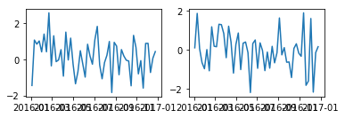

```python
x = df2.loc[df2.index.year==2016,['GrossOut']]
y = df2.loc[df2.index.year==2016,['GrossIn']]
plt.tight_layout()
plt.subplot(2,2,1)
plt.plot(x)
plt.subplot(2,2,2)
plt.plot(y)
```

**36) Plot 4 different HISTOGRAMS of df2.GrossIn each having 5,10,15,20 bins.**  
Hint: use the following code to plot the histograms on different subplots.

import matplotlib.pyplot as plt  
fig, ax = plt.subplots(nrows=2, ncols=2)  
dataframe.plot(ax=ax[0,0])# this is just an example of how to plot on a top right subplot (2x2)

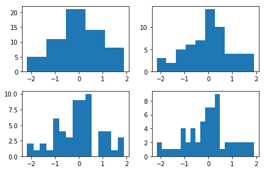

```python
#fig, ax = plt.subplots(nrows=2, ncols=2)
x = df2['GrossIn']

plt.subplot(2,2,1)
plt.hist(x, bins = 5)

plt.subplot(2,2,2)
plt.hist(x, bins = 10)

plt.subplot(2,2,3)
plt.hist(x, bins = 15)

plt.subplot(2,2,4)
plt.hist(x, bins = 20)

#df2.plot(ax=ax[0,0])

#df2['GrossIn'].plot(ax=ax[0,1])

#df2['GrossIn'].plot(ax=ax[1,0])

#df2['GrossIn'].plot(ax=ax[1,1])

plt.tight_layout()

#plt.subplot(2,2,1)
```

**37) What is your favorite pizza topping? None is not a valid answer. I don't care if you are off gluten.**

```python
salami
```

**38) Import pandas libary with the alias pd**

```python
import pandas as pd
```

**39)You are given the Medicare spending dataset. Read it into a pandas dataframe. Then remove the 2 unused columns 'Measure Start Date' and 'Measure End Date' from the DataFrame all in the following cell. Provide your code as the answer.**

*You need to put the data file ‘Medicare_Hospital_Spending_by_Claim.csv’ at the same place as your notebook file.*

```python
Medicare = pd.read_csv("Medicare_Hospital_Spending_by_Claim.csv", index_col = 0)
Medicare.drop(['Measure Start Date', 'Measure End Date'],axis = 'columns', inplace = True)
#print (Medicare.dtypes)
Medicare.head()
```

| Hospital Name | Provider Number | State | Period | Claim Type | Avg Spending Per Episode (Hospital) | Avg Spending Per Episode (State) | Avg Spending Per Episode (Nation) | Percent of Spending (Hospital) | Percent of Spending (State) | Percent of Spending (Nation) |
| --- | --- | --- | --- | --- | --- | --- | --- | --- | --- | --- |
| SOUTHEAST ALABAMA MEDICAL CENTER | 10001 | AL | 1 to 3 days Prior to Index Hospital Admission | Home Health Agency | $12 | $14 | $13 | 0.06% | 0.07% | 0.07% |
| SOUTHEAST ALABAMA MEDICAL CENTER | 10001 | AL | 1 to 3 days Prior to Index Hospital Admission | Hospice | $1 | $1 | $1 | 0.01% | 0.01% | 0% |
| SOUTHEAST ALABAMA MEDICAL CENTER | 10001 | AL | 1 to 3 days Prior to Index Hospital Admission | Inpatient | $6 | $6 | $5 | 0.03% | 0.03% | 0.03% |
| SOUTHEAST ALABAMA MEDICAL CENTER | 10001 | AL | 1 to 3 days Prior to Index Hospital Admission | Outpatient | $160 | $85 | $117 | 0.84% | 0.46% | 0.58% |
| SOUTHEAST ALABAMA MEDICAL CENTER | 10001 | AL | 1 to 3 days Prior to Index Hospital Admission | Skilled Nursing Facility | $1 | $2 | $2 | 0.01% | 0.01% | 0.01% |

**40) Continuing with data from above, convert the dataframe content to be the right "data type" (i.e., int, float, etc) in order to perform statistical calculations for the DataFrame. Provide your code and the resulting new print out as the answer.**  
*Hint convert the columns with % and $ using regex*

```python
#Medicare.dtypes
#Medicare.columns

#cols=Medicare.columns.values
#for key,value in Medicare.iteritems():
    #print key,value
 #   value.replace('$','')
  #  value.replace('%','')

#if key in cols[4:7]:
#        Medicare[key] = Medicare[key].astype(int)


#for x in range(4,7):
#Medicare.iloc[:,[0]]


#for x in range(7,10):
 #   Medicare.iloc[:,x] = Medicare.iloc[:,x].astype(float)

Medicare['Avg Spending Per Episode (Hospital)'] = Medicare['Avg Spending Per Episode (Hospital)'].str.replace('$','')
Medicare['Avg Spending Per Episode (State)'] = Medicare['Avg Spending Per Episode (State)'].str.replace('$','')
Medicare['Avg Spending Per Episode (Nation)'] = Medicare['Avg Spending Per Episode (Nation)'].str.replace('$','')
Medicare['Percent of Spending (Hospital)'] = Medicare['Percent of Spending (Hospital)'].str.replace('%','')
Medicare['Percent of Spending (State)'] = Medicare['Percent of Spending (State)'].str.replace('%','')
Medicare['Percent of Spending (Nation)'] = Medicare['Percent of Spending (Nation)'].str.replace('%','')


Medicare['Avg Spending Per Episode (Hospital)'] = Medicare['Avg Spending Per Episode (Hospital)'].astype(int)
Medicare['Avg Spending Per Episode (State)'] = Medicare['Avg Spending Per Episode (State)'].astype(int)
Medicare['Avg Spending Per Episode (Nation)'] = Medicare['Avg Spending Per Episode (Nation)'].astype(int)
Medicare['Percent of Spending (Hospital)'] = Medicare['Percent of Spending (Hospital)'].astype(float)
Medicare['Percent of Spending (State)'] = Medicare['Percent of Spending (State)'].astype(float)
Medicare['Percent of Spending (Nation)'] = Medicare['Percent of Spending (Nation)'].astype(float)

print (Medicare.dtypes)
Medicare.head()
```

```
Provider Number                          int64
State                                   object
Period                                  object
Claim Type                              object
Avg Spending Per Episode (Hospital)      int64
Avg Spending Per Episode (State)         int64
Avg Spending Per Episode (Nation)        int64
Percent of Spending (Hospital)         float64
Percent of Spending (State)            float64
Percent of Spending (Nation)           float64
dtype: object
```

| Hospital Name | Provider Number | State | Period | Claim Type | Avg Spending Per Episode (Hospital) | Avg Spending Per Episode (State) | Avg Spending Per Episode (Nation) | Percent of Spending (Hospital) | Percent of Spending (State) | Percent of Spending (Nation) |
| --- | --- | --- | --- | --- | --- | --- | --- | --- | --- | --- |
| SOUTHEAST ALABAMA MEDICAL CENTER | 10001 | AL | 1 to 3 days Prior to Index Hospital Admission | Home Health Agency | 12 | 14 | 13 | 0.06 | 0.07 | 0.07 |
| SOUTHEAST ALABAMA MEDICAL CENTER | 10001 | AL | 1 to 3 days Prior to Index Hospital Admission | Hospice | 1 | 1 | 1 | 0.01 | 0.01 | 0.00 |
| SOUTHEAST ALABAMA MEDICAL CENTER | 10001 | AL | 1 to 3 days Prior to Index Hospital Admission | Inpatient | 6 | 6 | 5 | 0.03 | 0.03 | 0.03 |
| SOUTHEAST ALABAMA MEDICAL CENTER | 10001 | AL | 1 to 3 days Prior to Index Hospital Admission | Outpatient | 160 | 85 | 117 | 0.84 | 0.46 | 0.58 |
| SOUTHEAST ALABAMA MEDICAL CENTER | 10001 | AL | 1 to 3 days Prior to Index Hospital Admission | Skilled Nursing Facility | 1 | 2 | 2 | 0.01 | 0.01 | 0.01 |

**41) Replace columns names...replace the original long column names in the dataframe above (Q - 39) with shorter ones provided below in "newColumns". Provide your code and the resulting new column names as the answer.**  
newColumns = ['Hospital', 'Provider ID', 'State', 'Period', 'Claim Type', 'Avg Spending Hospital', 'Avg Spending State', 'Avg Spending Nation', 'Percent Spending Hospital', 'Percent Spending State', 'Percent Spending Nation']

```python
newColumns = ['Hospital', 'Provider ID', 'State', 'Period', 'Claim Type', 'Avg Spending Hospital', 'Avg Spending State', 'Avg Spending Nation', 'Percent Spending Hospital', 'Percent Spending State', 'Percent Spending Nation']


Medicare.index.name = newColumns[0]
Medicare.columns = newColumns[1:]

#Medicare.index.names
Medicare.head()
```

| Hospital | Provider ID | State | Period | Claim Type | Avg Spending Hospital | Avg Spending State | Avg Spending Nation | Percent Spending Hospital | Percent Spending State | Percent Spending Nation |
| --- | --- | --- | --- | --- | --- | --- | --- | --- | --- | --- |
| SOUTHEAST ALABAMA MEDICAL CENTER | 10001 | AL | 1 to 3 days Prior to Index Hospital Admission | Home Health Agency | 12 | 14 | 13 | 0.06 | 0.07 | 0.07 |
| SOUTHEAST ALABAMA MEDICAL CENTER | 10001 | AL | 1 to 3 days Prior to Index Hospital Admission | Hospice | 1 | 1 | 1 | 0.01 | 0.01 | 0.00 |
| SOUTHEAST ALABAMA MEDICAL CENTER | 10001 | AL | 1 to 3 days Prior to Index Hospital Admission | Inpatient | 6 | 6 | 5 | 0.03 | 0.03 | 0.03 |
| SOUTHEAST ALABAMA MEDICAL CENTER | 10001 | AL | 1 to 3 days Prior to Index Hospital Admission | Outpatient | 160 | 85 | 117 | 0.84 | 0.46 | 0.58 |
| SOUTHEAST ALABAMA MEDICAL CENTER | 10001 | AL | 1 to 3 days Prior to Index Hospital Admission | Skilled Nursing Facility | 1 | 2 | 2 | 0.01 | 0.01 | 0.01 |

**42) Continuing with the dataframe above, extract only the TX state claims into a new dataframe. Provide your code and print the new dataframe (with only TX claims) below as the answer.**

```python
TX_Claims = Medicare[Medicare['State'] == 'TX']
TX_Claims.head()
```

| Hospital | Provider ID | State | Period | Claim Type | Avg Spending Hospital | Avg Spending State | Avg Spending Nation | Percent Spending Hospital | Percent Spending State | Percent Spending Nation |
| --- | --- | --- | --- | --- | --- | --- | --- | --- | --- | --- |
| PROVIDENCE MEMORIAL HOSPITAL | 450002 | TX | 1 to 3 days Prior to Index Hospital Admission | Home Health Agency | 52 | 23 | 13 | 0.27 | 0.11 | 0.07 |
| PROVIDENCE MEMORIAL HOSPITAL | 450002 | TX | 1 to 3 days Prior to Index Hospital Admission | Hospice | 0 | 1 | 1 | 0.00 | 0.01 | 0.00 |
| PROVIDENCE MEMORIAL HOSPITAL | 450002 | TX | 1 to 3 days Prior to Index Hospital Admission | Inpatient | 2 | 5 | 5 | 0.01 | 0.02 | 0.03 |
| PROVIDENCE MEMORIAL HOSPITAL | 450002 | TX | 1 to 3 days Prior to Index Hospital Admission | Outpatient | 80 | 122 | 117 | 0.41 | 0.57 | 0.58 |
| PROVIDENCE MEMORIAL HOSPITAL | 450002 | TX | 1 to 3 days Prior to Index Hospital Admission | Skilled Nursing Facility | 1 | 3 | 2 | 0.01 | 0.01 | 0.01 |

##### 43) Using the dataframe from above (Q 42), find the average spending for each different TX hospitals groupedby each kind of different claim types. Provide your code and the resulting new print out as the answer.

```python
TX_Claims.groupby(['Hospital','Claim Type'])['Avg Spending Hospital','Avg Spending State','Avg Spending Nation'].mean()

#Medicare.groupby(['Hospital','Claim Type']).mean()
```

| Hospital | Claim Type | Avg Spending Hospital | Avg Spending State | Avg Spending Nation |
| --- | --- | --- | --- | --- |
| ABILENE REGIONAL MEDICAL CENTER | Carrier | 988.666667 | 1119.666667 | 1043.000000 |
|  | Durable Medical Equipment | 42.333333 | 51.000000 | 44.666667 |
|  | Home Health Agency | 322.666667 | 293.666667 | 261.333333 |
|  | Hospice | 38.333333 | 48.666667 | 39.666667 |
|  | Inpatient | 4476.333333 | 4402.333333 | 3926.000000 |
|  | Outpatient | 281.666667 | 277.333333 | 275.666667 |
|  | Skilled Nursing Facility | 789.666667 | 968.666667 | 1084.333333 |
|  | Total | 20821.000000 | 21484.000000 | 20025.000000 |
| ANSON GENERAL HOSPITAL | Carrier | 341.000000 | 1119.666667 | 1043.000000 |
|  | Durable Medical Equipment | 24.666667 | 51.000000 | 44.666667 |
|  | Home Health Agency | 81.666667 | 293.666667 | 261.333333 |
|  | Hospice | 33.333333 | 48.666667 | 39.666667 |
|  | Inpatient | 2073.000000 | 4402.333333 | 3926.000000 |
|  | Outpatient | 275.666667 | 277.333333 | 275.666667 |
|  | Skilled Nursing Facility | 1013.333333 | 968.666667 | 1084.333333 |
|  | Total | 11528.000000 | 21484.000000 | 20025.000000 |
| ARISE AUSTIN MEDICAL CENTER | Carrier | 1105.666667 | 1119.666667 | 1043.000000 |
|  | Durable Medical Equipment | 73.666667 | 51.000000 | 44.666667 |
|  | Home Health Agency | 516.333333 | 293.666667 | 261.333333 |
|  | Hospice | 0.000000 | 48.666667 | 39.666667 |
|  | Inpatient | 4689.333333 | 4402.333333 | 3926.000000 |
|  | Outpatient | 76.333333 | 277.333333 | 275.666667 |
|  | Skilled Nursing Facility | 147.000000 | 968.666667 | 1084.333333 |
|  | Total | 19825.000000 | 21484.000000 | 20025.000000 |
| BAPTIST BEAUMONT HOSPITAL | Carrier | 935.666667 | 1119.666667 | 1043.000000 |
|  | Durable Medical Equipment | 36.333333 | 51.000000 | 44.666667 |
|  | Home Health Agency | 283.333333 | 293.666667 | 261.333333 |
|  | Hospice | 101.666667 | 48.666667 | 39.666667 |
|  | Inpatient | 4094.333333 | 4402.333333 | 3926.000000 |
|  | Outpatient | 263.666667 | 277.333333 | 275.666667 |
| ... | ... | ... | ... | ... |
| WILSON N. JONES REGIONAL MEDICAL CENTER | Home Health Agency | 289.333333 | 293.666667 | 261.333333 |
|  | Hospice | 81.666667 | 48.666667 | 39.666667 |
|  | Inpatient | 4071.333333 | 4402.333333 | 3926.000000 |
|  | Outpatient | 185.333333 | 277.333333 | 275.666667 |
|  | Skilled Nursing Facility | 1397.333333 | 968.666667 | 1084.333333 |
|  | Total | 21467.000000 | 21484.000000 | 20025.000000 |
| WISE REGIONAL HEALTH SYSTEM | Carrier | 1084.000000 | 1119.666667 | 1043.000000 |
|  | Durable Medical Equipment | 70.333333 | 51.000000 | 44.666667 |
|  | Home Health Agency | 330.333333 | 293.666667 | 261.333333 |
|  | Hospice | 58.000000 | 48.666667 | 39.666667 |
|  | Inpatient | 4312.666667 | 4402.333333 | 3926.000000 |
|  | Outpatient | 271.000000 | 277.333333 | 275.666667 |
|  | Skilled Nursing Facility | 1458.666667 | 968.666667 | 1084.333333 |
|  | Total | 22756.000000 | 21484.000000 | 20025.000000 |
| WOMANS HOSPITAL OF TEXAS,THE | Carrier | 876.333333 | 1119.666667 | 1043.000000 |
|  | Durable Medical Equipment | 30.666667 | 51.000000 | 44.666667 |
|  | Home Health Agency | 31.666667 | 293.666667 | 261.333333 |
|  | Hospice | 0.000000 | 48.666667 | 39.666667 |
|  | Inpatient | 2454.666667 | 4402.333333 | 3926.000000 |
|  | Outpatient | 126.666667 | 277.333333 | 275.666667 |
|  | Skilled Nursing Facility | 81.333333 | 968.666667 | 1084.333333 |
|  | Total | 10803.000000 | 21484.000000 | 20025.000000 |
| WOODLAND HEIGHTS MEDICAL CENTER | Carrier | 959.666667 | 1119.666667 | 1043.000000 |
|  | Durable Medical Equipment | 34.666667 | 51.000000 | 44.666667 |
|  | Home Health Agency | 262.666667 | 293.666667 | 261.333333 |
|  | Hospice | 34.333333 | 48.666667 | 39.666667 |
|  | Inpatient | 3640.333333 | 4402.333333 | 3926.000000 |
|  | Outpatient | 242.333333 | 277.333333 | 275.666667 |
|  | Skilled Nursing Facility | 893.000000 | 968.666667 | 1084.333333 |
|  | Total | 18199.000000 | 21484.000000 | 20025.000000 |

2352 rows × 3 columns

**44) Continuing from above (Q 43), what is the mean and max percentage spending of different TX hospitals for each different claim types. Provide your code and print out the answer.**

```python
#TX_Claims.head()
print TX_Claims.groupby(['Hospital','Claim Type'])['Percent Spending Hospital'].mean()

print ('*************************************'
       '**************************************')

print TX_Claims.groupby(['Hospital','Claim Type'])['Percent Spending Hospital'].max()

#Mean_Spending_Per.head()
#Max_Spending_Per.head()
```

```
Hospital                                 Claim Type
ABILENE REGIONAL MEDICAL CENTER          Carrier                        4.750000
                                         Durable Medical Equipment      0.203333
                                         Home Health Agency             1.550000
                                         Hospice                        0.183333
                                         Inpatient                     21.500000
                                         Outpatient                     1.353333
                                         Skilled Nursing Facility       3.793333
                                         Total                        100.000000
ANSON GENERAL HOSPITAL                   Carrier                        2.960000
                                         Durable Medical Equipment      0.213333
                                         Home Health Agency             0.706667
                                         Hospice                        0.290000
                                         Inpatient                     17.980000
                                         Outpatient                     2.390000
                                         Skilled Nursing Facility       8.790000
                                         Total                        100.000000
ARISE AUSTIN MEDICAL CENTER              Carrier                        5.576667
                                         Durable Medical Equipment      0.370000
                                         Home Health Agency             2.603333
                                         Hospice                        0.000000
                                         Inpatient                     23.656667
                                         Outpatient                     0.386667
                                         Skilled Nursing Facility       0.743333
                                         Total                        100.000000
BAPTIST BEAUMONT HOSPITAL                Carrier                        4.763333
                                         Durable Medical Equipment      0.186667
                                         Home Health Agency             1.443333
                                         Hospice                        0.520000
                                         Inpatient                     20.846667
                                         Outpatient                     1.343333
                                                                         ...
WILSON N. JONES REGIONAL MEDICAL CENTER  Home Health Agency             1.350000
                                         Hospice                        0.380000
                                         Inpatient                     18.963333
                                         Outpatient                     0.866667
                                         Skilled Nursing Facility       6.510000
                                         Total                        100.000000
WISE REGIONAL HEALTH SYSTEM              Carrier                        4.763333
                                         Durable Medical Equipment      0.306667
```

[output cut: 71 more lines]

```
                                         Home Health Agency             0.88
                                         Hospice                        0.00
                                         Inpatient                     60.20
                                         Outpatient                     2.28
                                         Skilled Nursing Facility       2.25
                                         Total                        100.00
WOODLAND HEIGHTS MEDICAL CENTER          Carrier                        7.86
                                         Durable Medical Equipment      0.46
                                         Home Health Agency             4.27
                                         Hospice                        0.57
                                         Inpatient                     48.01
                                         Outpatient                     3.35
                                         Skilled Nursing Facility      14.71
                                         Total                        100.00
Name: Percent Spending Hospital, Length: 2352, dtype: float64
```

45) The below DataFrame has a column of groups 'grps' and and column of numbers 'vals'.  
For each group, find the *sum of the three greatest values.***

```python
df = pd.DataFrame({'grps': list('aaabbcaabcccbbc'),
                   'vals': [12,345,3,1,45,14,4,52,54,23,235,21,57,3,87]})
grouped = df.groupby('grps')

for name,group in grouped:
    sorted_group=group.sort_values(by='vals')
    print (sorted_group[-3:].aggregate(np.sum))
```

```
grps    aaa
vals    409
dtype: object
grps    bbb
vals    156
dtype: object
grps    ccc
vals    345
dtype: object
```

**46) Some values in the values in the FlightNumber column are missing. These numbers are meant to increase by 10 with each row so 10055 and 10075 need to be put in place. Fill in these missing numbers and make the column an integer column (instead of a float column).** *Use the dataframe below*

```python
df = pd.DataFrame({'From_To': ['LoNDon_paris', 'MAdrid_miLAN', 'londON_StockhOlm','Budapest_PaRis','Brussels_londOn'],'FlightNumber': [10045, np.nan, 10065, np.nan, 10085],'RecentDelays': [[23, 47], [], [24, 43, 87], [13], [67, 32]],'Airline': ['KLM(!)', '<Air France> (12)', '(British Airways. )', '12. Air France', '"Swiss Air"']})
df
```

|  | Airline | FlightNumber | From_To | RecentDelays |
| --- | --- | --- | --- | --- |
| 0 | KLM(!) | 10045.0 | LoNDon_paris | [23, 47] |
| 1 | <Air France> (12) | NaN | MAdrid_miLAN | [] |
| 2 | (British Airways. ) | 10065.0 | londON_StockhOlm | [24, 43, 87] |
| 3 | 12. Air France | NaN | Budapest_PaRis | [13] |
| 4 | "Swiss Air" | 10085.0 | Brussels_londOn | [67, 32] |

```python
FlightNum = 10045
for i in range(5):
    df.loc[[i],['FlightNumber']] = FlightNum
    FlightNum = FlightNum + 10

df['FlightNumber'] = df['FlightNumber'].astype(int)

df.head()
```

|  | Airline | FlightNumber | From_To | RecentDelays |
| --- | --- | --- | --- | --- |
| 0 | KLM(!) | 10045 | LoNDon_paris | [23, 47] |
| 1 | <Air France> (12) | 10055 | MAdrid_miLAN | [] |
| 2 | (British Airways. ) | 10065 | londON_StockhOlm | [24, 43, 87] |
| 3 | 12. Air France | 10075 | Budapest_PaRis | [13] |
| 4 | "Swiss Air" | 10085 | Brussels_londOn | [67, 32] |

**47) Give a very general and short definition of what an Analytical Model is or is supposed to do?**

An analytical model estimates or classifies data values by essentially drawing a line through data points. When applied to new data or records, a model can predict outcomes based on historical patterns.

**48) Briefly describe the differences between "supervised" and "unsupervised" learning.**

Supervised Learning Training data consist of a set of training examples. Each example consists of an input object and a desired output value. It analyzes the training data and produces an inferred function, which can be used for mapping new examples and will allow for the algorithm to correctly determine the class labels for unseen instances. It requires the learning algorithm to generalize from the training data to unseen situations in a "reasonable" way. Unsupervised Learning The task of inferring a function to describe hidden structure from "unlabeled" data (a classification or categorization is not included in the observations). The examples given to the learner are unlabeled, there is no evaluation of the accuracy of the structure that is output by the relevant algorithm.

**49) Briefly describe the differences between "classification" and "clustering".**

The difference between "classification" and "clustering" is classification is unsupervised learning and the task of inferring a function to describe hidden structure from "unlabeled" data (a classification or categorization is not included in the observations).

Clustering is in the Data Mining which is the analysis of large quantities of data to extract previously unknown, interesting patterns such as groups of data records (cluster analysis), unusual records (anomaly detection), and dependencies (association rule mining, sequential pattern mining).

**50) Name 3 different "kinds" of Analytical Models and provide a brief definition of each.**

Statistical modeling:

It is a mathematical model where we can make assumptions about the generation of sample data and similar data from a larger population. It represent the data-generating process and describes a set of probability distributions that are assumed to approximate the distribution for a particular data set. It is specified by equations that relate one or more random variables and possibly other non-random variables.

Machine Learning:

It isfield of computer science which gives computers the ability to learn without being explicitly programmed. It evolved from the study of pattern recognition and computational learning theory in artificial intelligence and explores the study and construction of algorithms that can learn from and make predictions on data. It is sometimes conflated with data mining where the latter subfield focuses more on exploratory data analysis and is known as unsupervised learning. In the field of data analytics, machine learning is a method used to devise complex models and algorithms that lend themselves to prediction.

Data Mining:

It is computing process of discovering patterns in large data sets which involves methods at the intersection of machine learning, statistics, and database systems. It is an interdisciplinary subfield of computer science The overall goal s to extract information from a data set and transform it into an understandable structure for further use and involves database and data management aspects, data pre processing, model and inference considerations, post-processing of discovered structures, visualization, and online updating. This term is a misnomer because the goal is the extraction of patterns and knowledge from large amounts of data, not the extraction (mining) of data itself

**EXTRA CREDIT 51) Why is Ordinary Least Squares Regression, called Ordinary Least Squares?**

Ordinary Least Squares Regression is called Ordinary Least Squares which is a method for performing linear regression. It is called Ordinary Least Squares because it chooses the parameters of a linear function of a set of explanatory variables by minimizing the sum of the squares of the differences between the observed dependent variable (values of the variable being predicted) in the given dataset and those predicted by the linear function.

**EXTRA CREDIT 52) Why do vicious feedback loops matter in data analytics?**

```python
vicious circle refer to complex chains of events that reinforce themselves through a feedback loop.
vicious feedback loops matter in data analytics because the vicious circle has detrimental results in the short run.
Vicious feedback loops in which each iteration of the cycle reinforces the previous one (positive feedback).
```

**EXTRA CREDIT 53) What are the 10 simple rules Zook et. al. Suggest to follow when doing big data analytics?**

```python
1. Acknowledge that data are people and can do harm
2. Recognize that privacy is more than a binary value
3. Guard against the reidentification of your data
4. Practice ethical data sharing
5. Consider the strengths and limitations of your data; big does not automatically mean better
6. Debate the tough, ethical choices
7. Develop a code of conduct for your organization, research community, or industry
8. Design your data and systems for auditability
9. Engage with the broader consequences of data and analysis practices
10. Know when to break these rules
```